# Bellabeat Google Capstone Project

Brian Towner

2022-10-20

## Introduction

Bellabeat is a wellness brand for women that sells products and services focussed on women’s health. The founders Urska Srsen and Sando Mur have asked for an analysis of smart device usage in order to gain insight into how people already use smart devices. They are looking for high-level recommendations for how these trends can inform their marketing strategy.

## Ask Phase

What are some trends in smart device usage?

How could these trends apply to Bellabeat customers?

How could these trends help influence Bellabeat marketing strategy?

#### Business Task

I am trying to boost sales for bellabeat by deriving insights from Fitbit Data collected by Morbius. I intend to identify trends in smart device usage. I plan to make predictions based off of these trends to boost sales of specific bellabeat products.

## Prepare Phase

Source:

We will be using the dataset FitBit Fitness Tracker Data uploaded by Mobius found at https://www.kaggle.com/datasets/arashnic/fitbit. This data contains personal fitness tracker data from 30 or so eligible users with many different metrics.

#### Does my Data ROCCC?

Reliable - I do not think this data is reliable. It contains only 33 participants at most per table. This is no where near a good sample size for making decisions for smart device users as a whole.

Original - This is 3rd party collected by user Morbius. This data was not provided by Fitbit or bellabeat

Comprehensive - Certain tables in this dataset are comprehensive, but not all of them as we will see. It also only covers one month of time which is not a big enough time frame.

Current - This data is from 2016. If we were closer to 2016 this would be current, but I believe it is no longer current.

Cited - This data is not cited to a reputable source. It is self classified as a Crowd-sourced survey on https://zenodo.org/record/53894#.Y1Gk9XbMLCZ

Overall, my data does not ROCCC and I would not move forth with this dataset. Because this is just and exercise, we will move forward.

Let’s upload our data and install some packages

```r
#Loading Packages
library(tidyverse)
library(janitor)
```

```r
library(dplyr)
library(ggplot2)
library(lubridate)
library(readr)

#Let's now import our dataframes
daily_activity <- read_csv("C:/Users/brian/Desktop/Fitabase Data 4.12.16-5.12.16/dailyActivity_merged.csv")
daily_calories <- read_csv("C:/Users/brian/Desktop/Fitabase Data 4.12.16-5.12.16/dailyCalories_merged.csv")
daily_steps <- read_csv("C:/Users/brian/Desktop/Fitabase Data 4.12.16-5.12.16/dailySteps_merged.csv")
daily_intensities <- read_csv("C:/Users/brian/Desktop/Fitabase Data 4.12.16-5.12.16/dailyIntensities_merged.csv")
sleep_day <- read_csv("C:/Users/brian/Desktop/Fitabase Data 4.12.16-5.12.16/sleepDay_merged.csv")
```

Let’s take a look out what our data frames look like now that we have them loaded in.

```r
#Let's see what our tables look like. I like the glimpse function because it shows me all column names and data types in a compact format.
glimpse(daily_activity)
```

```
## Rows: 940
## Columns: 15
## $ Id                       <dbl> 1503960366, 1503960366, 1503960366, 150396036…
## $ ActivityDate             <chr> "4/12/2016", "4/13/2016", "4/14/2016", "4/15/…
## $ TotalSteps               <dbl> 13162, 10735, 10460, 9762, 12669, 9705, 13019…
## $ TotalDistance            <dbl> 8.50, 6.97, 6.74, 6.28, 8.16, 6.48, 8.59, 9.8…
## $ TrackerDistance          <dbl> 8.50, 6.97, 6.74, 6.28, 8.16, 6.48, 8.59, 9.8…
## $ LoggedActivitiesDistance <dbl> 0, 0, 0, 0, 0, 0, 0, 0, 0, 0, 0, 0, 0, 0, 0, …
## $ VeryActiveDistance       <dbl> 1.88, 1.57, 2.44, 2.14, 2.71, 3.19, 3.25, 3.5…
## $ ModeratelyActiveDistance <dbl> 0.55, 0.69, 0.40, 1.26, 0.41, 0.78, 0.64, 1.3…
## $ LightActiveDistance      <dbl> 6.06, 4.71, 3.91, 2.83, 5.04, 2.51, 4.71, 5.0…
## $ SedentaryActiveDistance  <dbl> 0, 0, 0, 0, 0, 0, 0, 0, 0, 0, 0, 0, 0, 0, 0, …
## $ VeryActiveMinutes        <dbl> 25, 21, 30, 29, 36, 38, 42, 50, 28, 19, 66, 4…
## $ FairlyActiveMinutes      <dbl> 13, 19, 11, 34, 10, 20, 16, 31, 12, 8, 27, 21…
## $ LightlyActiveMinutes     <dbl> 328, 217, 181, 209, 221, 164, 233, 264, 205, …
## $ SedentaryMinutes         <dbl> 728, 776, 1218, 726, 773, 539, 1149, 775, 818…
## $ Calories                 <dbl> 1985, 1797, 1776, 1745, 1863, 1728, 1921, 203…
```

```r
glimpse(daily_calories)
```

```
## Rows: 940
## Columns: 3
## $ Id          <dbl> 1503960366, 1503960366, 1503960366, 1503960366, 1503960366…
## $ ActivityDay <chr> "4/12/2016", "4/13/2016", "4/14/2016", "4/15/2016", "4/16/…
## $ Calories    <dbl> 1985, 1797, 1776, 1745, 1863, 1728, 1921, 2035, 1786, 1775…
```

```r
glimpse(daily_steps)
```

```
## Rows: 940
## Columns: 3
## $ Id          <dbl> 1503960366, 1503960366, 1503960366, 1503960366, 1503960366…
## $ ActivityDay <chr> "4/12/2016", "4/13/2016", "4/14/2016", "4/15/2016", "4/16/…
## $ StepTotal   <dbl> 13162, 10735, 10460, 9762, 12669, 9705, 13019, 15506, 1054…
```

```r
glimpse(sleep_day)
```

```
## Rows: 413
## Columns: 5
## $ Id                 <dbl> 1503960366, 1503960366, 1503960366, 1503960366, 150…
## $ SleepDay           <chr> "4/12/2016 12:00:00 AM", "4/13/2016 12:00:00 AM", "…
## $ TotalSleepRecords  <dbl> 1, 2, 1, 2, 1, 1, 1, 1, 1, 1, 1, 1, 1, 1, 1, 1, 1, …
## $ TotalMinutesAsleep <dbl> 327, 384, 412, 340, 700, 304, 360, 325, 361, 430, 2…
## $ TotalTimeInBed     <dbl> 346, 407, 442, 367, 712, 320, 377, 364, 384, 449, 3…
```

```r
glimpse(daily_intensities)
```

```
## Rows: 940
## Columns: 10
## $ Id                       <dbl> 1503960366, 1503960366, 1503960366, 150396036…
## $ ActivityDay              <chr> "4/12/2016", "4/13/2016", "4/14/2016", "4/15/…
## $ SedentaryMinutes         <dbl> 728, 776, 1218, 726, 773, 539, 1149, 775, 818…
## $ LightlyActiveMinutes     <dbl> 328, 217, 181, 209, 221, 164, 233, 264, 205, …
## $ FairlyActiveMinutes      <dbl> 13, 19, 11, 34, 10, 20, 16, 31, 12, 8, 27, 21…
## $ VeryActiveMinutes        <dbl> 25, 21, 30, 29, 36, 38, 42, 50, 28, 19, 66, 4…
## $ SedentaryActiveDistance  <dbl> 0, 0, 0, 0, 0, 0, 0, 0, 0, 0, 0, 0, 0, 0, 0, …
## $ LightActiveDistance      <dbl> 6.06, 4.71, 3.91, 2.83, 5.04, 2.51, 4.71, 5.0…
## $ ModeratelyActiveDistance <dbl> 0.55, 0.69, 0.40, 1.26, 0.41, 0.78, 0.64, 1.3…
## $ VeryActiveDistance       <dbl> 1.88, 1.57, 2.44, 2.14, 2.71, 3.19, 3.25, 3.5…
```

OK, we’ve got some issues with some of the data types and names that we can fix later. Let’s check how many participants each table has. The dataset describes it as having 30 participants total.

```r
daily_activity %>%
  count(Id) %>%
  glimpse()
```

```
## Rows: 33
## Columns: 2
## $ Id <dbl> 1503960366, 1624580081, 1644430081, 1844505072, 1927972279, 2022484…
## $ n  <int> 31, 31, 30, 31, 31, 31, 31, 31, 18, 31, 20, 30, 31, 4, 31, 31, 31, …
```

```r
daily_calories%>%
  count(Id)%>%
    glimpse()
```

```
## Rows: 33
## Columns: 2
## $ Id <dbl> 1503960366, 1624580081, 1644430081, 1844505072, 1927972279, 2022484…
## $ n  <int> 31, 31, 30, 31, 31, 31, 31, 31, 18, 31, 20, 30, 31, 4, 31, 31, 31, …
```

```r
daily_steps%>%
  count(Id)%>%
    glimpse()
```

```
## Rows: 33
## Columns: 2
## $ Id <dbl> 1503960366, 1624580081, 1644430081, 1844505072, 1927972279, 2022484…
## $ n  <int> 31, 31, 30, 31, 31, 31, 31, 31, 18, 31, 20, 30, 31, 4, 31, 31, 31, …
```

```r
sleep_day%>%
  count(Id)%>%
    glimpse()
```

```
## Rows: 24
## Columns: 2
## $ Id <dbl> 1503960366, 1644430081, 1844505072, 1927972279, 2026352035, 2320127…
## $ n  <int> 25, 4, 3, 5, 28, 1, 15, 28, 8, 26, 24, 28, 5, 28, 31, 26, 18, 3, 31…
```

```r
daily_intensities%>%
    count(Id)%>%
    glimpse()
```

```
## Rows: 33
## Columns: 2
## $ Id <dbl> 1503960366, 1624580081, 1644430081, 1844505072, 1927972279, 2022484…
## $ n  <int> 31, 31, 30, 31, 31, 31, 31, 31, 18, 31, 20, 30, 31, 4, 31, 31, 31, …
```

It appears that we have 33 participants for each dataframe except for sleep_day. We’ll move on in spite of that.

## Process Phase

Let’s clean our names, remove duplicate entries, rename our date columns so that they match between sataframes, and mutate the date columns to show as Date data types.

```r
daily_activity <- daily_activity%>%
    clean_names() %>%
    distinct() %>%
    rename(activity_day = activity_date) %>%
    mutate(activity_day=as.Date(activity_day, format = "%m/%d/%Y"))

daily_calories <- daily_calories%>%
    clean_names() %>%
    distinct() %>%
    mutate(activity_day=as.Date(activity_day, format = "%m/%d/%Y"))

daily_steps <- daily_steps%>%
    clean_names() %>%
    distinct() %>%
    mutate(activity_day=as.Date(activity_day, format = "%m/%d/%Y"))

daily_intensities <- daily_intensities %>%
    clean_names() %>%
    mutate(activity_day=as.Date(activity_day, format = "%m/%d/%Y"))

sleep_day <- sleep_day %>%
    clean_names() %>%
    mutate(sleep_day=as.Date(sleep_day, format = "%m/%d/%Y"))
```

```r
sum(is.na(daily_activity))
```

```
## [1] 0
```

```r
sum(is.na(daily_calories))
```

```
## [1] 0
```

```r
sum(is.na(daily_steps))
```

```
## [1] 0
```

```r
sum(is.na(daily_intensities))
```

```
## [1] 0
```

```r
sum(is.na(sleep_day))
```

```
## [1] 0
```

Let’s see what we have now.

```r
glimpse(daily_activity)
```

```
## Rows: 940
## Columns: 15
## $ id                         <dbl> 1503960366, 1503960366, 1503960366, 1503960…
## $ activity_day               <date> 2016-04-12, 2016-04-13, 2016-04-14, 2016-0…
## $ total_steps                <dbl> 13162, 10735, 10460, 9762, 12669, 9705, 130…
## $ total_distance             <dbl> 8.50, 6.97, 6.74, 6.28, 8.16, 6.48, 8.59, 9…
## $ tracker_distance           <dbl> 8.50, 6.97, 6.74, 6.28, 8.16, 6.48, 8.59, 9…
## $ logged_activities_distance <dbl> 0, 0, 0, 0, 0, 0, 0, 0, 0, 0, 0, 0, 0, 0, 0…
## $ very_active_distance       <dbl> 1.88, 1.57, 2.44, 2.14, 2.71, 3.19, 3.25, 3…
## $ moderately_active_distance <dbl> 0.55, 0.69, 0.40, 1.26, 0.41, 0.78, 0.64, 1…
## $ light_active_distance      <dbl> 6.06, 4.71, 3.91, 2.83, 5.04, 2.51, 4.71, 5…
## $ sedentary_active_distance  <dbl> 0, 0, 0, 0, 0, 0, 0, 0, 0, 0, 0, 0, 0, 0, 0…
## $ very_active_minutes        <dbl> 25, 21, 30, 29, 36, 38, 42, 50, 28, 19, 66,…
## $ fairly_active_minutes      <dbl> 13, 19, 11, 34, 10, 20, 16, 31, 12, 8, 27, …
## $ lightly_active_minutes     <dbl> 328, 217, 181, 209, 221, 164, 233, 264, 205…
## $ sedentary_minutes          <dbl> 728, 776, 1218, 726, 773, 539, 1149, 775, 8…
## $ calories                   <dbl> 1985, 1797, 1776, 1745, 1863, 1728, 1921, 2…
```

```r
glimpse(daily_calories)
```

```
## Rows: 940
## Columns: 3
## $ id           <dbl> 1503960366, 1503960366, 1503960366, 1503960366, 150396036…
## $ activity_day <date> 2016-04-12, 2016-04-13, 2016-04-14, 2016-04-15, 2016-04-…
## $ calories     <dbl> 1985, 1797, 1776, 1745, 1863, 1728, 1921, 2035, 1786, 177…
```

```r
glimpse(daily_steps)
```

```
## Rows: 940
## Columns: 3
## $ id           <dbl> 1503960366, 1503960366, 1503960366, 1503960366, 150396036…
## $ activity_day <date> 2016-04-12, 2016-04-13, 2016-04-14, 2016-04-15, 2016-04-…
## $ step_total   <dbl> 13162, 10735, 10460, 9762, 12669, 9705, 13019, 15506, 105…
```

```r
glimpse(daily_intensities)
```

```
## Rows: 940
## Columns: 10
## $ id                         <dbl> 1503960366, 1503960366, 1503960366, 1503960…
## $ activity_day               <date> 2016-04-12, 2016-04-13, 2016-04-14, 2016-0…
## $ sedentary_minutes          <dbl> 728, 776, 1218, 726, 773, 539, 1149, 775, 8…
## $ lightly_active_minutes     <dbl> 328, 217, 181, 209, 221, 164, 233, 264, 205…
## $ fairly_active_minutes      <dbl> 13, 19, 11, 34, 10, 20, 16, 31, 12, 8, 27, …
## $ very_active_minutes        <dbl> 25, 21, 30, 29, 36, 38, 42, 50, 28, 19, 66,…
## $ sedentary_active_distance  <dbl> 0, 0, 0, 0, 0, 0, 0, 0, 0, 0, 0, 0, 0, 0, 0…
## $ light_active_distance      <dbl> 6.06, 4.71, 3.91, 2.83, 5.04, 2.51, 4.71, 5…
## $ moderately_active_distance <dbl> 0.55, 0.69, 0.40, 1.26, 0.41, 0.78, 0.64, 1…
## $ very_active_distance       <dbl> 1.88, 1.57, 2.44, 2.14, 2.71, 3.19, 3.25, 3…
```

```r
glimpse(sleep_day)
```

```
## Rows: 413
## Columns: 5
## $ id                   <dbl> 1503960366, 1503960366, 1503960366, 1503960366, 1…
## $ sleep_day            <date> 2016-04-12, 2016-04-13, 2016-04-15, 2016-04-16, …
## $ total_sleep_records  <dbl> 1, 2, 1, 2, 1, 1, 1, 1, 1, 1, 1, 1, 1, 1, 1, 1, 1…
## $ total_minutes_asleep <dbl> 327, 384, 412, 340, 700, 304, 360, 325, 361, 430,…
## $ total_time_in_bed    <dbl> 346, 407, 442, 367, 712, 320, 377, 364, 384, 449,…
```

It appears that our daily_intensities table data is also included in the daily_activity table so we will not include that table in our analysis. The same is for daily_steps and daily_calories. It looks like the daily_activity table has everything that we need.

I would also like to add a day of the week column to daily_activity for analysis later.

```r
daily_activity$weekday <- wday(daily_activity$activity_day, label=TRUE)

sleep_day$weekday <- wday(sleep_day$sleep_day, label=TRUE)

glimpse(daily_activity)
```

```
## Rows: 940
## Columns: 16
## $ id                         <dbl> 1503960366, 1503960366, 1503960366, 1503960…
## $ activity_day               <date> 2016-04-12, 2016-04-13, 2016-04-14, 2016-0…
## $ total_steps                <dbl> 13162, 10735, 10460, 9762, 12669, 9705, 130…
## $ total_distance             <dbl> 8.50, 6.97, 6.74, 6.28, 8.16, 6.48, 8.59, 9…
## $ tracker_distance           <dbl> 8.50, 6.97, 6.74, 6.28, 8.16, 6.48, 8.59, 9…
## $ logged_activities_distance <dbl> 0, 0, 0, 0, 0, 0, 0, 0, 0, 0, 0, 0, 0, 0, 0…
## $ very_active_distance       <dbl> 1.88, 1.57, 2.44, 2.14, 2.71, 3.19, 3.25, 3…
## $ moderately_active_distance <dbl> 0.55, 0.69, 0.40, 1.26, 0.41, 0.78, 0.64, 1…
## $ light_active_distance      <dbl> 6.06, 4.71, 3.91, 2.83, 5.04, 2.51, 4.71, 5…
## $ sedentary_active_distance  <dbl> 0, 0, 0, 0, 0, 0, 0, 0, 0, 0, 0, 0, 0, 0, 0…
## $ very_active_minutes        <dbl> 25, 21, 30, 29, 36, 38, 42, 50, 28, 19, 66,…
## $ fairly_active_minutes      <dbl> 13, 19, 11, 34, 10, 20, 16, 31, 12, 8, 27, …
## $ lightly_active_minutes     <dbl> 328, 217, 181, 209, 221, 164, 233, 264, 205…
## $ sedentary_minutes          <dbl> 728, 776, 1218, 726, 773, 539, 1149, 775, 8…
## $ calories                   <dbl> 1985, 1797, 1776, 1745, 1863, 1728, 1921, 2…
## $ weekday                    <ord> Tue, Wed, Thu, Fri, Sat, Sun, Mon, Tue, Wed…
```

```r
glimpse(sleep_day)
```

```
## Rows: 413
## Columns: 6
## $ id                   <dbl> 1503960366, 1503960366, 1503960366, 1503960366, 1…
## $ sleep_day            <date> 2016-04-12, 2016-04-13, 2016-04-15, 2016-04-16, …
## $ total_sleep_records  <dbl> 1, 2, 1, 2, 1, 1, 1, 1, 1, 1, 1, 1, 1, 1, 1, 1, 1…
## $ total_minutes_asleep <dbl> 327, 384, 412, 340, 700, 304, 360, 325, 361, 430,…
## $ total_time_in_bed    <dbl> 346, 407, 442, 367, 712, 320, 377, 364, 384, 449,…
## $ weekday              <ord> Tue, Wed, Fri, Sat, Sun, Tue, Wed, Thu, Sat, Sun,…
```

Our data is not cleaned and ready for Analysis

## Analysis/Share

Let’s start by seeing if there are any specific days of the week where people wear their device more or less than others. This bar chart will sum the number of entries per day of the week. The more entries there are, the more people wear their device.

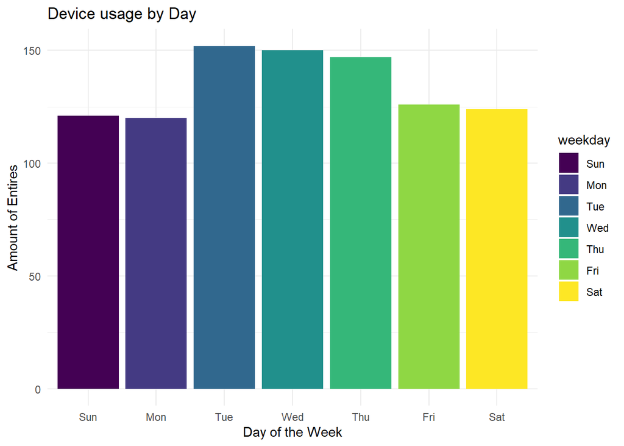

```r
ggplot(daily_activity)+
    geom_bar(mapping = aes(weekday, fill=weekday))+
    labs(x = "Day of the Week", y= "Amount of Entires", title="Device usage by Day")+
  theme_minimal()
```

It looks like more people wear their devices in the middle of the week. I wonder why that is. Let’s see if another bar graph can help us out.

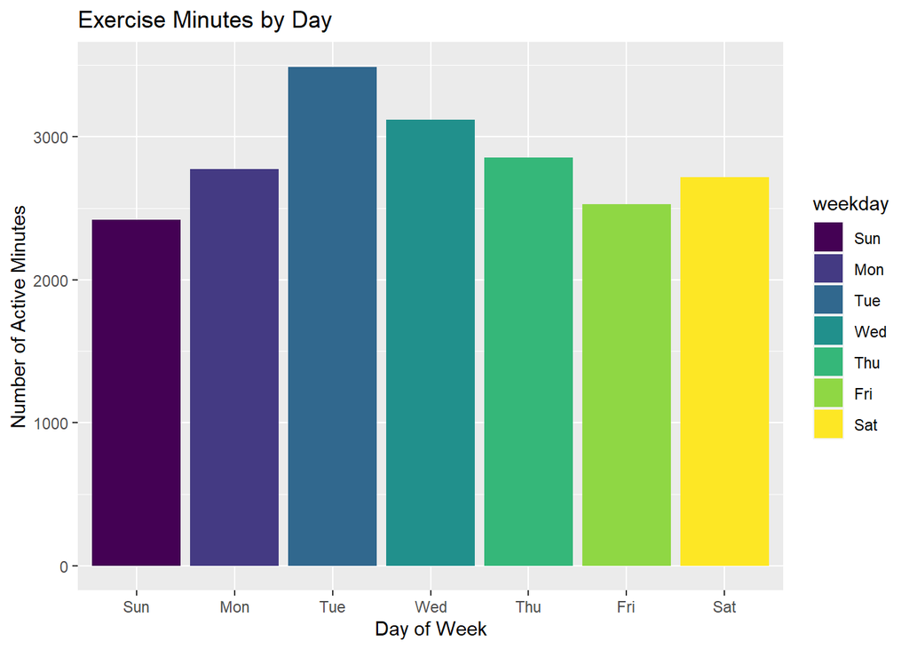

```r
ggplot(daily_activity)+
  geom_col(mapping = aes(x=weekday, y=very_active_minutes,fill = weekday))+
  labs(x="Day of Week", y= "Number of Active Minutes", title = "Exercise Minutes by Day")
```

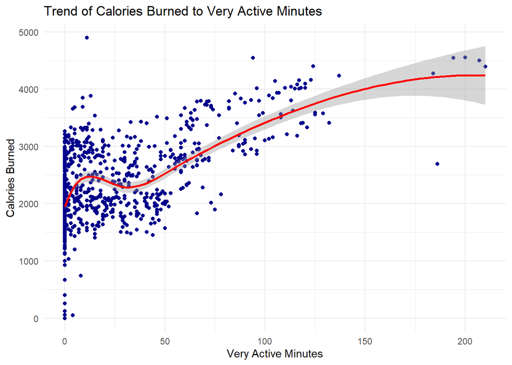

```r
ggplot(daily_activity)+
  geom_point(mapping=aes(x=very_active_minutes, y=calories),color="dark blue")+
  geom_smooth(mapping=aes(x=very_active_minutes, y=calories), color = "red", formula = y~x, method = "loess")+
  labs(x="Very Active Minutes", y="Calories Burned", title = "Trend of Calories Burned to Very Active Minutes")+
  theme_minimal()
```

We see a clear trend here that the more “Very Active Minutes” we have, the more calories we burn. Let’s now look at “Fairly Active Minutes”

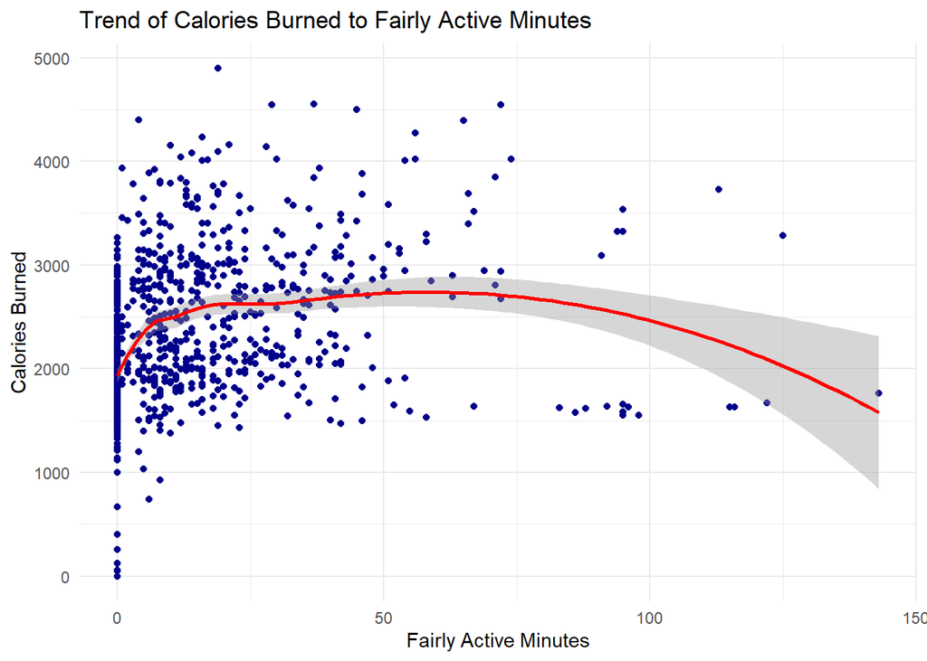

```r
ggplot(daily_activity)+
  geom_point(mapping=aes(x=fairly_active_minutes, y=calories),color="dark blue")+
  geom_smooth(mapping=aes(x=fairly_active_minutes, y=calories), color = "red",formula = y~x, method = "loess")+
  labs(x="Fairly Active Minutes", y="Calories Burned", title = "Trend of Calories Burned to Fairly Active Minutes")+
  theme_minimal()
```

Our data does not show as much of a positive correlation as the “Very Active Minutes”. Lastly, let’s see what the “Sedentary Minutes” trend shows.

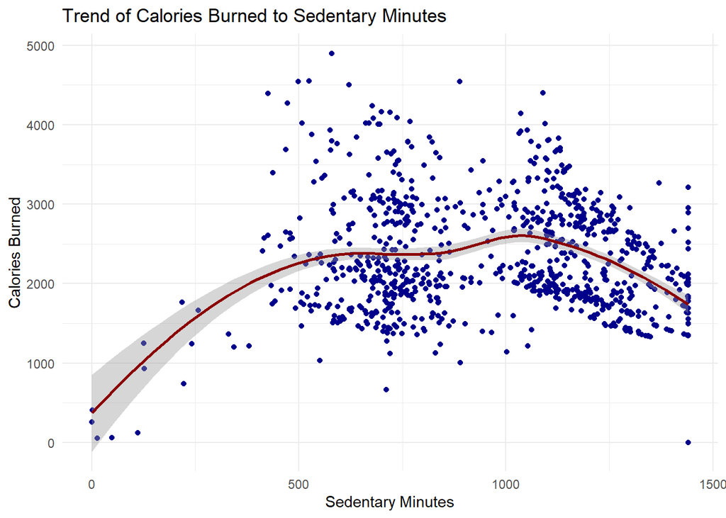

```r
ggplot(daily_activity)+
  geom_point(mapping=aes(x=sedentary_minutes, y=calories),color="dark blue")+
  geom_smooth(mapping=aes(x=sedentary_minutes, y=calories), color = "dark red", formula = y~x, method = "loess")+
  labs(x="Sedentary Minutes", y="Calories Burned", title = "Trend of Calories Burned to Sedentary Minutes")+
  theme_minimal()
```

Our body burns calories to maintain normal bodily functions which is why you see an upward trend in the beginning of the chart. What is interesting and not surprising is that just past 1000 minutes, or 16.67 hours, our amount of calories burned dips off. I would deduce that if we were trying to lose weight, we could have less Sedentary time and more Fairly or Very active time to increase caloric burn.

Lastly, let’s see how our people are sleeping.

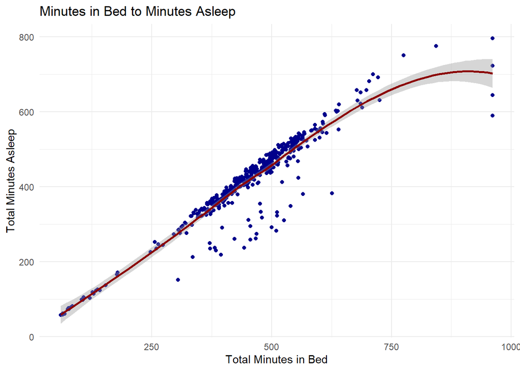

```r
ggplot(sleep_day)+
  geom_point(mapping=aes(x=total_time_in_bed, y=total_minutes_asleep),color="dark blue")+
  geom_smooth(mapping=aes(x=total_time_in_bed, y=total_minutes_asleep), color = "dark red", formula = y~x, method = "loess")+
  labs(x="Total Minutes in Bed", y="Total Minutes Asleep", title = "Minutes in Bed to Minutes Asleep")+
  theme_minimal()
```

It makes sense that the more we are in bed, the more we tend to sleep. Good to see a positive correlation.

Let’s see if we sleep more or less on certain days of the week.

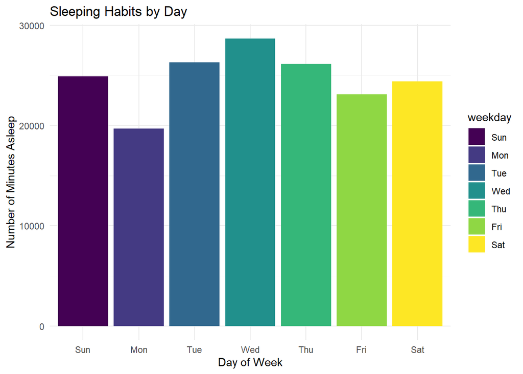

```r
ggplot(sleep_day)+
  geom_col(mapping = aes(x=weekday, y=(total_minutes_asleep),fill = weekday))+
  labs(x="Day of Week", y= "Number of Minutes Asleep", title = "Sleeping Habits by Day")+
  theme_minimal()
```

## Recommendations

How are users using their smart devices?

- They are NOT using their devices as a whole to log their activities. This should not be an included feature in future bellabeat products.
- They are also not as engaged at tracking their sleep based off of the only 24 participants that tracked their sleep and they did not do so all that regulary.
- I think that we can build on getting our users to track their wellness more regularly by creating an incentive system like the other big time players are using. A “close the rings” every day this month sort of system.
- I also think we should focus on the tacking of stress and menstrual cycles, because as of now we have no data on that and I think that could make bellabeat a leader in that area.